# Data Loading; Preparation; Summarising

Rohan Dalmia

2022-05-14

# Problem 1

[figure not shown]

*As part of the Deloitte Audit of Dunder Mifflin for FY15, you are tasked with identifying any irregularities in the company’s general ledger. These irregularities could be anything from an accidental typo (i.e., an extra 0) to a calculated fraud. You are assisting the audit team to apply the best of Data Science to form risk based hypothesis. The general ledger houses a company’s accounts and many journal entries are posted to these accounts to either credit or debit balances. When checking journal entries for outliers, typically a rules-based analysis is performed, such as identifying manually entered journals that:*

- Do not net to zero
- Are above a particular amount
- Are posted by people that post relatively few journals
- Are round amounts (i.e. $32,000)
- Have particular words in the narration (note: the descriptive columns were omitted to preserve the anonymity of the data)
- Are posted by certain people (i.e. the CEO)

Your task is to use any analytical technique of your choice to identify outliers or anomalies in this dataset. It does not have to follow the typical rules-based approach above, but we are most interested in identifying journal postings that do not look like ‘business as usual’. Note: The data used in this case study is of journal entries – financial postings to a company’s general ledger. It has been anonymised by masking the true value of several descriptive fields, removing some identifying columns and randomising the journal amounts by a random factor.

### Assumptions

- Assuming Dunder Mifflin is a paper company that has an annual revenue of `$100,000,000`. We set the materiality to be 1% of the revenue - `$1,000,000` and the clearly trivial threshold (CTT) to be `$10,000`.
- We are only interested in looking at the manual entries. Thus, most of the analysis will be on these entries.
- Users who post less than **5%** of the entries will be subjected to investigation.
- For clustering, the business unit of interest is **2**

### Approach

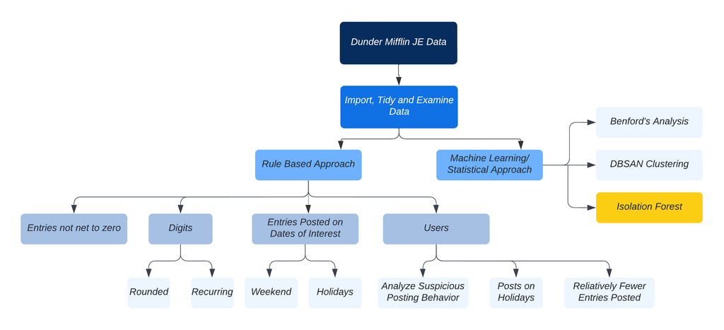

### Data Read In

- Breakdown of data types -

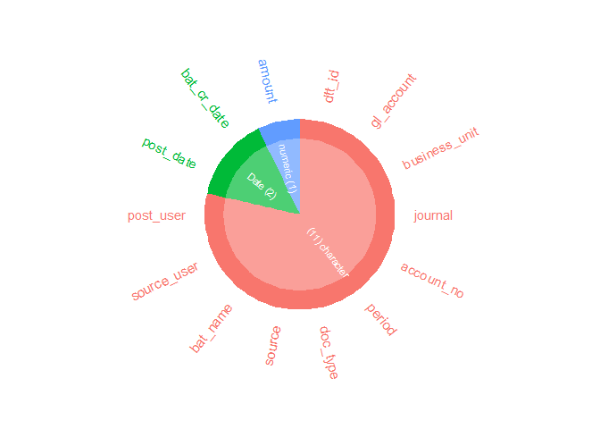

- Data sizing information -

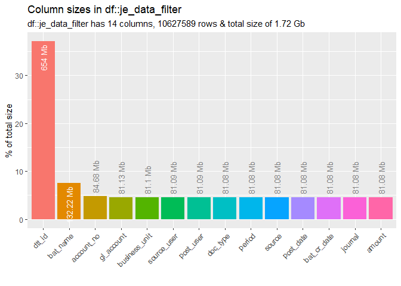

### Exploration & Insights

##### Amount Total

| Amount |
| --- |
| $95,499.9 |

We would expect the amount to net to zero, since all the journal entries are supposed to net.

##### Date Ranges

Since the data provided from Dunder Mifflin is an FY15 data, we would expect all the entries to be effective during FY15.

**Post Date:**

| Min | Max |
| --- | --- |
| 2014-07-02 | 2015-08-13 |

**Bat Cr Date:**

| Min | Max |
| --- | --- |
| 2014-05-11 | 2015-08-09 |

**Period summary with dates**

| Period | Min Posted Date | Max Posted Date | Min Bat Cr Date | Max Bat Cr Date |
| --- | --- | --- | --- | --- |
| 1 | 2014-07-02 | 2015-08-07 | 2014-05-11 | 2015-08-03 |
| 2 | 2014-07-12 | 2015-07-09 | 2014-06-01 | 2015-07-05 |
| 3 | 2014-07-26 | 2015-07-09 | 2014-06-16 | 2015-07-05 |
| 4 | 2014-09-11 | 2015-07-09 | 2014-08-16 | 2015-07-05 |
| 5 | 2014-10-16 | 2015-07-09 | 2014-08-13 | 2015-07-05 |
| 6 | 2014-11-15 | 2015-07-09 | 2014-09-01 | 2015-07-05 |
| 7 | 2014-12-10 | 2015-07-09 | 2014-11-13 | 2015-07-05 |
| 8 | 2015-01-23 | 2015-07-09 | 2014-11-19 | 2015-07-05 |
| 9 | 2015-02-23 | 2015-07-09 | 2014-12-07 | 2015-07-05 |
| 10 | 2015-03-04 | 2015-07-13 | 2015-01-25 | 2015-07-09 |
| 11 | 2015-04-16 | 2015-07-12 | 2015-02-15 | 2015-07-08 |
| 12 | 2014-07-31 | 2015-08-13 | 2014-07-27 | 2015-08-09 |
| 13 | 2015-06-07 | 2015-07-10 | 2015-06-03 | 2015-07-06 |

Even though the date ranges don’t align with the period and none of the dates seem to be potential effective dates, I’m making the assumption that `post_date` is the date the entries were posted on and will be using it for my analysis.

##### 1. Entries above a particular amount

The plots below show the distribution of our population based on the materiality and CTT values chosen -

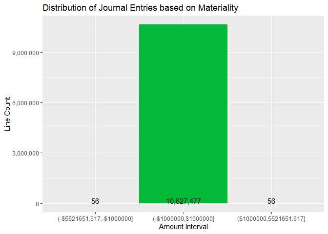

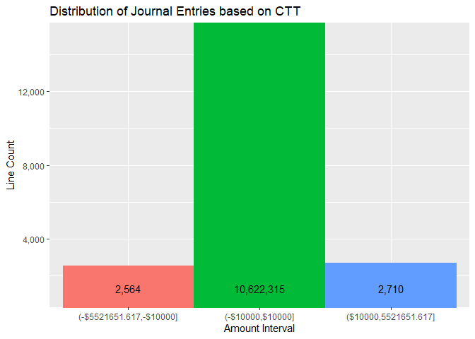

##### 2. Manual entries that do not net to zero

There are 342 manual entries that do not net to zero. Out of these, the entries above CTT that do not net to zero -

| JEID | Amount | Debit | Credit | Line Count |
| --- | --- | --- | --- | --- |
| BAT_NAME 398438 | $6,287.257 | $50,373.33 | $44,086.07 | 9 |
| BAT_NAME 52137 | $-5,732.078 | $51,661.33 | $57,393.41 | 491 |
| BAT_NAME 87512 | $2,756.521 | $18,140.84 | $15,384.32 | 76 |
| BAT_NAME 219236 | $2,727.384 | $19,315.95 | $16,588.57 | 92 |
| BAT_NAME 178934 | $1,756.400 | $23,863.43 | $22,107.03 | 93 |
| BAT_NAME 44754 | $1,351.472 | $42,462.05 | $41,110.58 | 231 |

Entries in the above table are worth looking into, since they do not net to zero. The ones with even line count could be worth bringing up to the client, as opposed to the odd ones, which suggest a potential missing entry.

##### 3. Manual entries posted on a weekend/ holiday

- Scraped holiday calendar from 2015
- Performed a join with `post_date`

| DAY | DATE | HOLIDAY |
| --- | --- | --- |
| Thursday | 2015-01-01 | New Year's Day |
| Monday | 2015-01-26 | Australia Day |
| Monday | 2015-03-02 | Labour Day (WA) |
| Monday | 2015-03-09 | Eight Hours Day (TAS) |
| Friday | 2015-04-03 | Good Friday |
| Sunday | 2015-04-05 | Easter Sunday |
| Monday | 2015-04-06 | Easter Monday |
| Saturday | 2015-04-25 | Anzac Day |
| Monday | 2015-05-04 | May Day (NT, QLD) |
| Monday | 2015-06-08 | Queen's Birthday (Most regions) |
| Monday | 2015-09-28 | Queen's Birthday (WA) |
| Monday | 2015-10-05 | Labour Day (SA, ACT, NSW) |
| Wednesday | 2015-11-11 | Remembrance Day |
| Friday | 2015-12-25 | Christmas Day |
| Saturday | 2015-12-26 | Boxing Day |
| Thursday | 2015-12-31 | New Year's Eve |

- Manual entries posted on holiday -

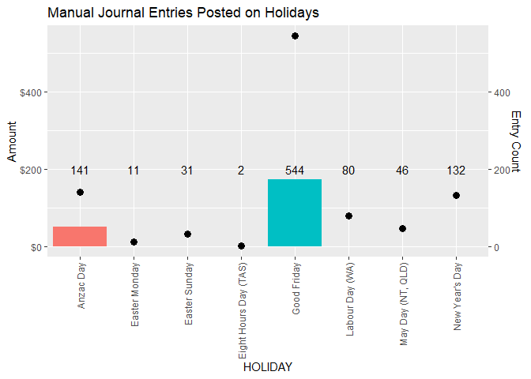

These entries could potentially indicate fraudulent entries that could have been posted without permission or a management override.

- Entries posted on Saturday/ Sunday -

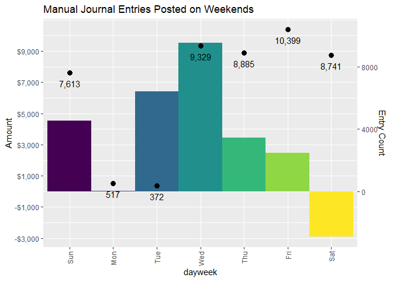

Similarly, if the company doesn’t work on weekends, there should be no reason to see entries being posted on Saturdays and Sundays.

##### 4. Manual entries posted by users analysis

- Looking at all the user posting manual journal entries to find potential patterns -

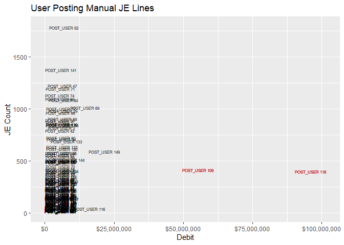

Since Post User 109 and 118 stand out, we will dig deeper into their posting behaviors

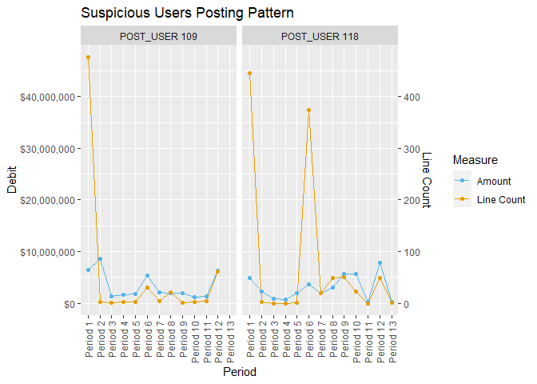

From the above plot, we can see that Post User 118 posted few high dollar amount entries in period 6, while Post User 109 exhibited similar behavior in period 1.

Taking a glimpse at the amounts of these unusual months -

| Post User | Period | Amount | Debit | Credit | Entries Posted |
| --- | --- | --- | --- | --- | --- |
| POST_USER 109 | Period 1 | $5,732.08 | $47,613,591 | 47,619,323 | 65 |
| POST_USER 109 | Period 6 | $0.00 | $3,084,646 | 3,084,646 | 53 |
| POST_USER 118 | Period 1 | $0.00 | $44,519,228 | 44,519,228 | 49 |
| POST_USER 118 | Period 6 | $0.00 | $37,481,312 | 37,481,312 | 36 |

- Looking at users that post less than 5% of the manual journal entries -

| Post User | Amount | Debit | Credit | Entries Posted |
| --- | --- | --- | --- | --- |
| POST_USER 69 | $6,385.19 | $9,066,174.4 | $9,059,789.2 | 1,027 |
| POST_USER 118 | $6,287.28 | $101,549,112.4 | $101,542,825.1 | 382 |
| POST_USER 73 | $2,851.19 | $248,672.8 | $245,821.6 | 259 |
| POST_USER 120 | $2,781.34 | $514,671.5 | $511,890.2 | 598 |
| POST_USER 58 | $2,242.89 | $942,114.6 | $939,871.7 | 922 |
| POST_USER 34 | $1,762.20 | $683,906.8 | $682,144.6 | 691 |
| POST_USER 85 | $1,147.20 | $787,873.7 | $786,726.5 | 559 |

We can look into the titles of these users to identify any potential management override. Post User 118 pops up again!

- Users who posted on a holidays -

| JEID | Post User | Holiday | Amount | Debit | Credit | Count |
| --- | --- | --- | --- | --- | --- | --- |
| BAT_NAME 385962 | POST_USER 47 | Good Friday | $46,745.75 | $46,745.746 | 0.000 | 1 |
| BAT_NAME 428744 | POST_USER 29 | May Day (NT, QLD) | $45,566.30 | $45,566.305 | 0.000 | 1 |
| BAT_NAME 386276 | POST_USER 29 | Good Friday | $44,614.64 | $44,614.638 | 0.000 | 1 |
| BAT_NAME 386076 | POST_USER 32 | Good Friday | $41,925.87 | $193,909.894 | 151,984.024 | 9 |
| BAT_NAME 386362 | POST_USER 2 | Good Friday | $40,860.29 | $40,860.292 | 0.000 | 1 |
| BAT_NAME 386037 | POST_USER 58 | Good Friday | $34,949.69 | $34,949.685 | 0.000 | 1 |
| BAT_NAME 414735 | POST_USER 118 | Anzac Day | $0.00 | $7,454.664 | 7,454.664 | 10 |

There were 21 unique users who posted entries on holidays above the set CTT of `$10,000`.

##### 5. Recurring digits, round amount and Benford’s

- Recurring Digit

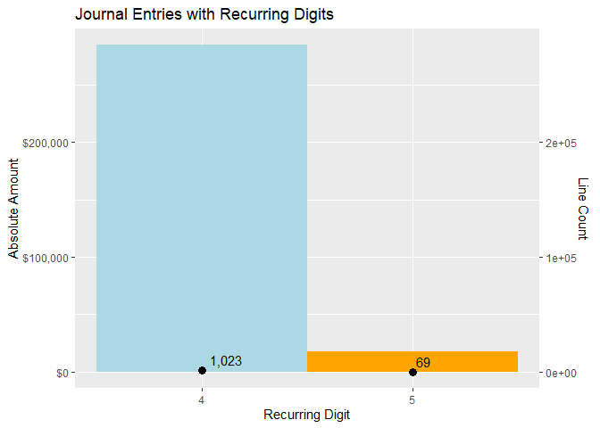

| JEID | Amount |
| --- | --- |
| BAT_NAME 53713 | $3,398,533.33 |
| BAT_NAME 132683 | $86,666.74 |
| BAT_NAME 50361 | $48,888.58 |
| BAT_NAME 520525 | $37,653.00 |
| BAT_NAME 473101 | $11,112.21 |
| BAT_NAME 132141 | $10,712.22 |

Recurring digits could indicate potential fradulent entries and looking deeper into the description of those above CTT, it might be worth reaching out to the client.

- Round Amount

| JEID | Round Amount |
| --- | --- |
| BAT_NAME 517128 | $10.0 |
| BAT_NAME 150787 | $1.0 |
| BAT_NAME 184183 | $1.0 |
| BAT_NAME 390555 | $1.0 |
| BAT_NAME 107128 | $0.1 |
| BAT_NAME 127168 | $0.1 |

Since these amounts are a lot smaller than our CTT, we can ignore them.

- Benford’s Analysis -

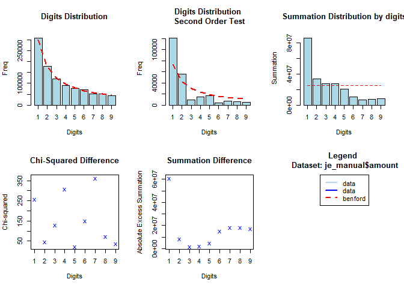

While there is close conformity to Benford’s distribution here, we can infer that there are more 7’s than expected based on the chi-square plot. We also see the sum of these 7’s is not meeting the average mark. This suggests there are significant low dollar value entries with leading digit 7.

##### 6. Duplicate Entries

The above table shows entries that contain the same combination of line accounts amounts for different JEIDs and are above threshold.

| JEID | Account Number | Amount |
| --- | --- | --- |
| BAT_NAME 126656 | Account No 48171 | 1815252.76 |
| BAT_NAME 126656 | Account No 48948 | 1815252.76 |
| BAT_NAME 126678 | Account No 48171 | 1815252.76 |
| BAT_NAME 126678 | Account No 48948 | 1815252.76 |
| BAT_NAME 126678 | Account No 48951 | 1815252.76 |
| BAT_NAME 126683 | Account No 48949 | 1815252.76 |
| BAT_NAME 126683 | Account No 48951 | 1815252.76 |
| BAT_NAME 126741 | Account No 48949 | 1815252.76 |
| BAT_NAME 126741 | Account No 48951 | 1815252.76 |
| BAT_NAME 126742 | Account No 48949 | 1815252.76 |
| BAT_NAME 126742 | Account No 48951 | 1815252.76 |
| BAT_NAME 136392 | Account No 3830 | 12119.89 |
| BAT_NAME 149266 | Account No 3576 | 13331.87 |

The highlighted rows would be worth looking into with the client.

##### 7. DBSCAN

Feature Engineering

- Cyclic encoding of dates
- Addition of recurring digits, day of the week, holiday boolean to the data
- Scaling amount
- Filtered data to business unit `2`

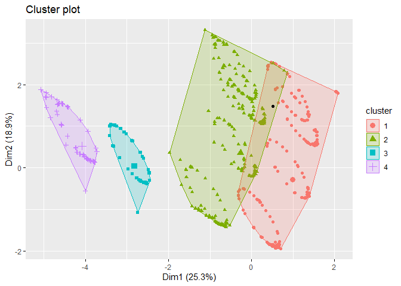

| JEID | Amount | Debit | Credit | Day of Week |
| --- | --- | --- | --- | --- |
| BAT_NAME 518551 | $-33.3333 | $0 | $33.3333 | 6 |